[figure not shown]

# **PYTHON FOR DATA SCIENCE**

## **Visaulisation**

### **Matplotlib & Seaborn**

Matplotlib is a Python 2D plotting library which produces publication quality figures in a variety of hardcopy formats and interactive environments across platforms. Matplotlib can be used in Python scripts, the Python and IPython shells, the Jupyter notebook, web application servers, and four graphical user interface toolkits.

*Third party packages*

A large number of third party packages extend and build on Matplotlib functionality, including several higher-level plotting interfaces (seaborn, holoviews, ggplot, ...), and two projection and mapping toolkits (basemap and cartopy).

matplotlib.pyplot is a collection of command style functions that make matplotlib work like MATLAB. Each pyplot function makes some change to a figure: e.g., creates a figure, creates a plotting area in a figure, plots some lines in a plotting area, decorates the plot with labels, etc.

In matplotlib.pyplot various states are preserved across function calls, so that it keeps track of things like the current figure and plotting area, and the plotting functions are directed to the current axes (please note that "axes" here and in most places in the documentation refers to the axes part of a figure and not the strict mathematical term for more than one axis).

Tip: In Jupyter Notebook, you can also include %matplotlib inline to display your plots inside your notebook.

## **Load the required libraries**

```python
import numpy as np
import pandas as pd

import matplotlib.pyplot as plt

%matplotlib inline #to be able to plot inside my jupyter notebook
```

```python
#plt.plot?
```

# **Plot a point**

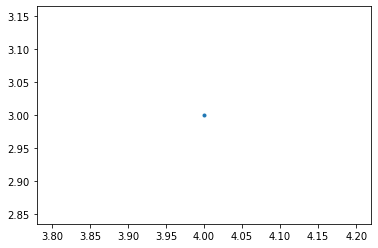

```python
plt.plot(4, 3, '.')
```

# **Plot number of points**

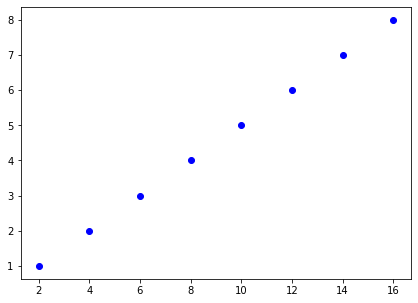

```python
x = np.array([2,4,6,8,10,12,14,16])
y = x/2

plt.figure(figsize=(7,5))
plt.scatter(x, y, c='blue')
plt.show()
```

# **Label the axes**

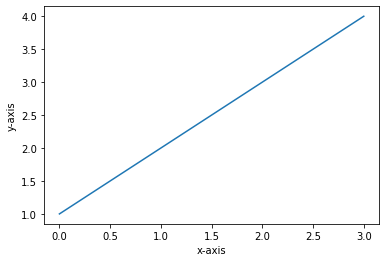

```python
plt.plot([1, 2, 3, 4])
plt.ylabel('y-axis')
plt.xlabel('x-axis')
plt.show()
```

# **Create multiple plots with subplots**

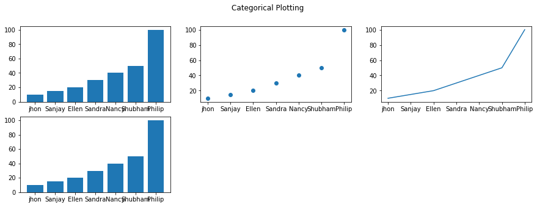

```python
names = ['jhon', 'Sanjay', 'Ellen','Sandra','Nancy','Shubham','Philip']
scores = [10,15,20,30,40,50,100]

plt.figure(figsize=(15, 5))

plt.subplot(231)
plt.bar(names, scores)

plt.subplot(232)
plt.scatter(names, scores)

plt.subplot(233)
plt.plot(names, scores)

plt.subplot(234)
plt.bar(names, scores)


plt.suptitle('Categorical Plotting')       #you can give titles,xlabels and ylabels to each of the plots as well
plt.show()
```

**What are the differences between add_axes and add_subplot?**

The calling signature of add_axes is add_axes(rect), where rect is a list [x0, y0, width, height] denoting the lower left point of the new axes in figure coodinates (x0,y0) and its width and height. So the axes is positionned in absolute coordinates on the canvas

The calling signature of add_subplot does not directly provide the option to place the axes at a predefined position. It rather allows to specify where the axes should be situated according to a subplot grid. The usual and easiest way to specify this position is the 3 integer notation,

e.g. ax = fig.add_subplot(231)

In this example a new axes is created at the first position (1) on a grid of 2 rows and 3 columns. To produce only a single axes, add_subplot(111) would be used (First plot on a 1 by 1 subplot grid). (In newer matplotlib versions, add_subplot()` without any arguments is possible as well.)

# **Seaborn**

Seaborn comes with a large number of high-level interfaces and customized themes that matplotlib lacks as it becomes difficult to figure out the settings that make plots attractive.

Mostly, matplotlib functions don’t work well with dataframes as seaborn does.

NB: Seaborn visualisations are based on matplotlib

```python
import seaborn as sns
```

**Let's load a dataset to be used**

```python
ourdata=pd.read_excel("Pokemon.xls")
```

```python
ourdata.head(20)
```

|  | Name | Type 1 | Type 2 | Total | HP | Attack | Defense | Atk | Def | Speed | Stage | Legendary |
| --- | --- | --- | --- | --- | --- | --- | --- | --- | --- | --- | --- | --- |
| 0 | Bulbasaur | Grass | Poison | 318 | 45 | 49 | 49 | 65 | 65 | 45 | 1 | False |
| 1 | Ivysaur | Grass | Poison | 405 | 60 | 62 | 63 | 80 | 80 | 60 | 2 | False |
| 2 | Venusaur | Grass | Poison | 525 | 80 | 82 | 83 | 100 | 100 | 80 | 3 | False |
| 3 | Charmander | Fire | NaN | 309 | 39 | 52 | 43 | 60 | 50 | 65 | 1 | False |
| 4 | Charmeleon | Fire | NaN | 405 | 58 | 64 | 58 | 80 | 65 | 80 | 2 | False |
| 5 | Charizard | Fire | Flying | 534 | 78 | 84 | 78 | 109 | 85 | 100 | 3 | False |
| 6 | Squirtle | Water | NaN | 314 | 44 | 48 | 65 | 50 | 64 | 43 | 1 | False |
| 7 | Wartortle | Water | NaN | 405 | 59 | 63 | 80 | 65 | 80 | 58 | 2 | False |
| 8 | Blastoise | Water | NaN | 530 | 79 | 83 | 100 | 85 | 105 | 78 | 3 | False |
| 9 | Caterpie | Bug | NaN | 195 | 45 | 30 | 35 | 20 | 20 | 45 | 1 | False |
| 10 | Metapod | Bug | NaN | 205 | 50 | 20 | 55 | 25 | 25 | 30 | 2 | False |
| 11 | Butterfree | Bug | Flying | 395 | 60 | 45 | 50 | 90 | 80 | 70 | 3 | False |
| 12 | Weedle | Bug | Poison | 195 | 40 | 35 | 30 | 20 | 20 | 50 | 1 | False |
| 13 | Kakuna | Bug | Poison | 205 | 45 | 25 | 50 | 25 | 25 | 35 | 2 | False |
| 14 | Beedrill | Bug | Poison | 395 | 65 | 90 | 40 | 45 | 80 | 75 | 3 | False |
| 15 | Pidgey | Normal | Flying | 251 | 40 | 45 | 40 | 35 | 35 | 56 | 1 | False |
| 16 | Pidgeotto | Normal | Flying | 349 | 63 | 60 | 55 | 50 | 50 | 71 | 2 | False |
| 17 | Pidgeot | Normal | Flying | 479 | 83 | 80 | 75 | 70 | 70 | 101 | 3 | False |
| 18 | Rattata | Normal | NaN | 253 | 30 | 56 | 35 | 25 | 35 | 72 | 1 | False |
| 19 | Raticate | Normal | NaN | 413 | 55 | 81 | 60 | 50 | 70 | 97 | 2 | False |

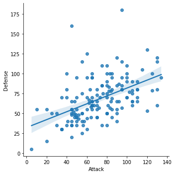

```python
sns.lmplot('Attack','Defense', data=ourdata) #lmplot() function is used to quickly plot the Linear Relationship between two(2) variables. lm for linear regression model
plt.show()
```

[figure not shown]

**No regression line and adding hue**

Setting fit_reg=False to remove the regression line

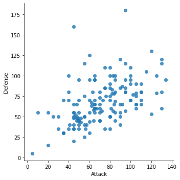

```python
sns.lmplot(x='Attack', y='Defense', data=ourdata,fit_reg=False)
```

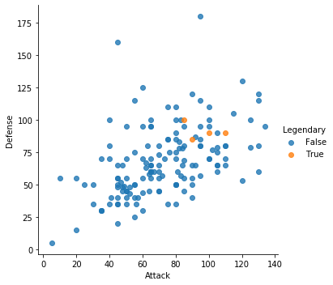

```python
sns.lmplot(x='Attack', y='Defense', data=ourdata,fit_reg=False,hue='Legendary')
```

```python
ourdata['Legendary'].value_counts()
```

```
False    147
True       4
Name: Legendary, dtype: int64
```

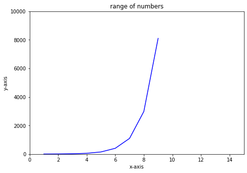

```python
fig = plt.figure()
a1 = fig.add_axes([0,0,1,1]) #The calling signature of add_axes is add_axes(rect), where rect is a list [x0, y0, width, height] denoting the lower left point of the new axes in figure coodinates (x0,y0) and its width and height. So the axes is positionned in absolute coordinates on the canvas

x = np.arange(1,10)
a1.plot(x, np.exp(x),'b')

a1.set_title('range of numbers')

#explicitly set x and y limits
plt.ylim(0,10000)
plt.xlim(0,15)

#explicitly set x and y labels
plt.xlabel("x-axis")
plt.ylabel('y-axis')
plt.show()
```

```python
ourdata.tail()
```

|  | Name | Type 1 | Type 2 | Total | HP | Attack | Defense | Atk | Def | Speed | Stage | Legendary |
| --- | --- | --- | --- | --- | --- | --- | --- | --- | --- | --- | --- | --- |
| 146 | Dratini | Dragon | NaN | 300 | 41 | 64 | 45 | 50 | 50 | 50 | 1 | False |
| 147 | Dragonair | Dragon | NaN | 420 | 61 | 84 | 65 | 70 | 70 | 70 | 2 | False |
| 148 | Dragonite | Dragon | Flying | 600 | 91 | 134 | 95 | 100 | 100 | 80 | 3 | False |
| 149 | Mewtwo | Psychic | NaN | 680 | 106 | 110 | 90 | 154 | 90 | 130 | 1 | True |
| 150 | Mew | Psychic | NaN | 600 | 100 | 100 | 100 | 100 | 100 | 100 | 1 | False |

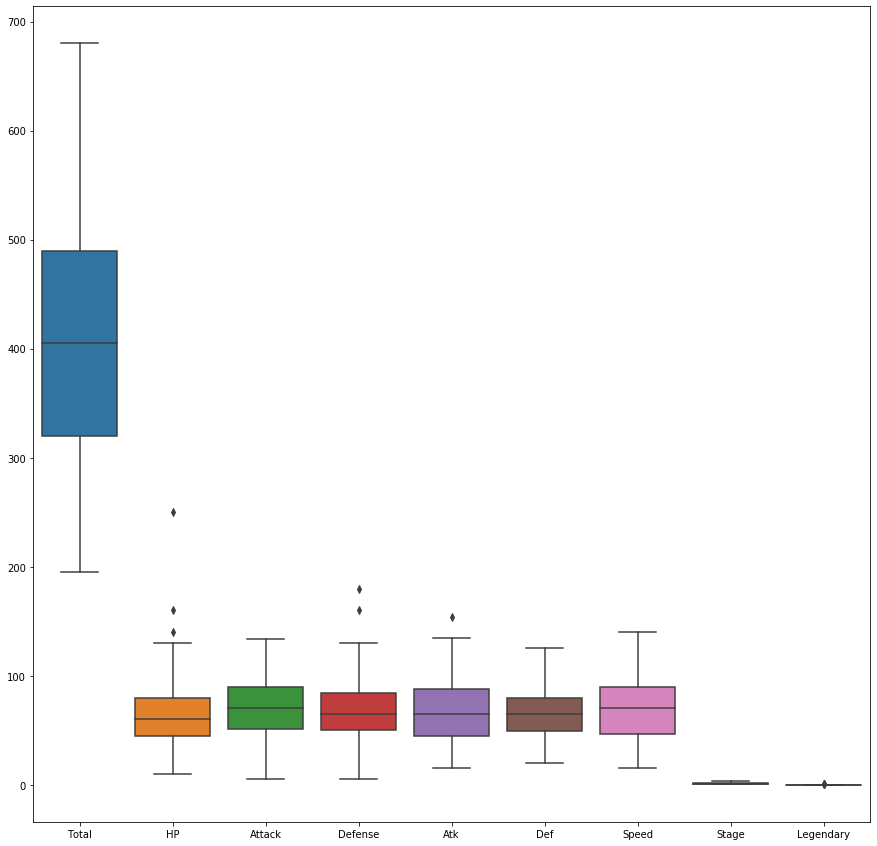

```python
plt.figure(figsize=(15,15))
sns.boxplot(data=ourdata)
```

```python
#drop the unwanted columns
ourdata1=ourdata.drop(['Total','Legendary','Stage'],axis=1)
ourdata1.head()
```

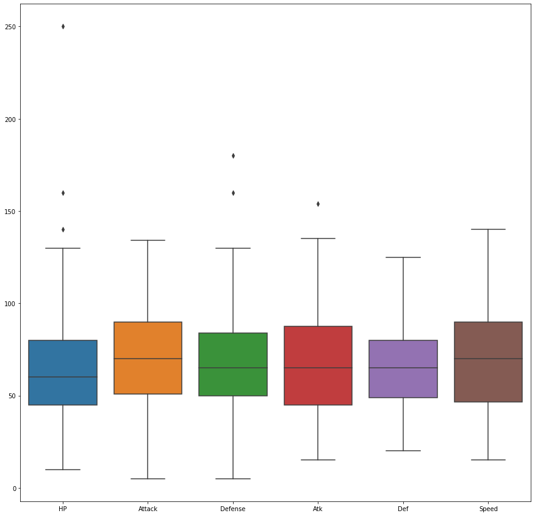

```python
plt.figure(figsize=(15,15))
sns.boxplot(data=ourdata1)
```

```python
corr = ourdata1.corr()  # Calculate correlations

corr
```

|  | HP | Attack | Defense | Atk | Def | Speed |
| --- | --- | --- | --- | --- | --- | --- |
| HP | 1.000000 | 0.306768 | 0.119782 | 0.236649 | 0.490978 | -0.040939 |
| Attack | 0.306768 | 1.000000 | 0.491965 | 0.146312 | 0.369069 | 0.194701 |
| Defense | 0.119782 | 0.491965 | 1.000000 | 0.187569 | 0.139912 | -0.053252 |
| Atk | 0.236649 | 0.146312 | 0.187569 | 1.000000 | 0.522907 | 0.411516 |
| Def | 0.490978 | 0.369069 | 0.139912 | 0.522907 | 1.000000 | 0.392656 |
| Speed | -0.040939 | 0.194701 | -0.053252 | 0.411516 | 0.392656 | 1.000000 |

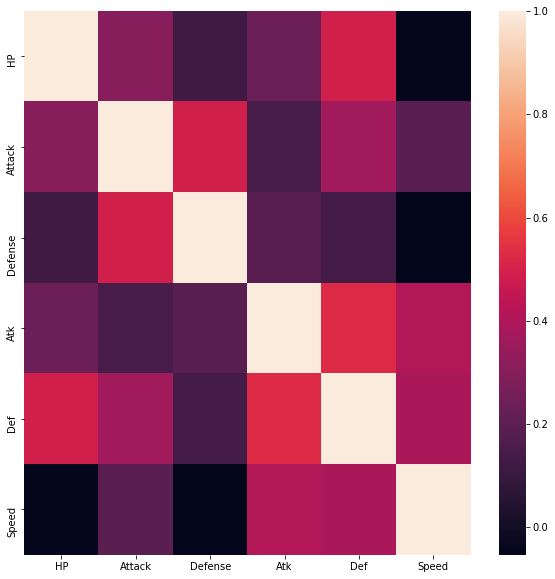

```python
plt.figure(figsize=(10,10))
sns.heatmap(corr)  # Creating Heatmap
```

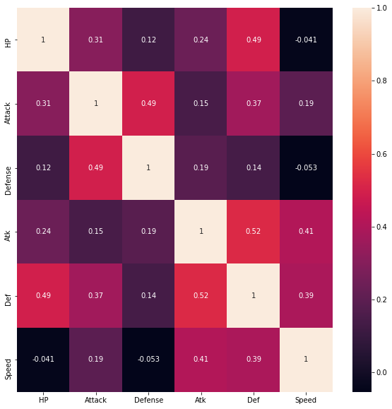

```python
plt.figure(figsize=(10,10))
sns.heatmap(corr,annot=True)
```

```python
ourdata1.head()
```

|  | Name | Type 1 | Type 2 | HP | Attack | Defense | Atk | Def | Speed |
| --- | --- | --- | --- | --- | --- | --- | --- | --- | --- |
| 0 | Bulbasaur | Grass | Poison | 45 | 49 | 49 | 65 | 65 | 45 |
| 1 | Ivysaur | Grass | Poison | 60 | 62 | 63 | 80 | 80 | 60 |
| 2 | Venusaur | Grass | Poison | 80 | 82 | 83 | 100 | 100 | 80 |
| 3 | Charmander | Fire | NaN | 39 | 52 | 43 | 60 | 50 | 65 |
| 4 | Charmeleon | Fire | NaN | 58 | 64 | 58 | 80 | 65 | 80 |

## **Univariate Visualisation**

## **Distplot**

The most convenient way to take a quick look at a univariate distribution in seaborn is the distplot() function. By default, this will draw a histogram and fit a kernel density estimate (KDE). It is used basically for univariant set of observations and visualizes it through a histogram i.e. only one observation and hence we choose one particular column of the dataset.

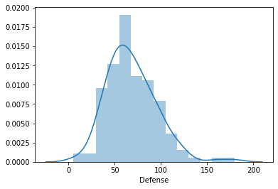

```python
sns.distplot(ourdata1['Defense'])
```

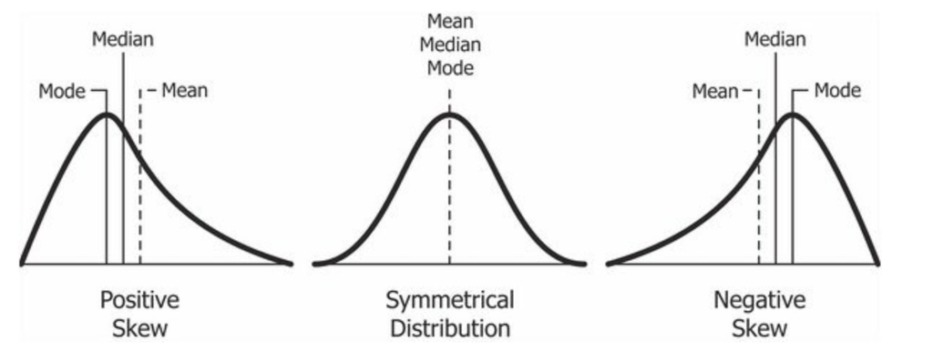

use boxplot to confirm your disttribution

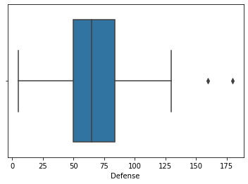

```python
sns.boxplot(ourdata1['Defense'])
```

**You can explicitly turn off the kde**

read about kde: https://pythontic.com/pandas/series-plotting/kernel%20density%20estimation%20plot

https://pythontic.com/pandas/dataframe-plotting/kernel%20density%20estimation%20plot

https://en.wikipedia.org/wiki/Kernel_density_estimation

https://www.statsmodels.org/stable/examples/notebooks/generated/kernel_density.html

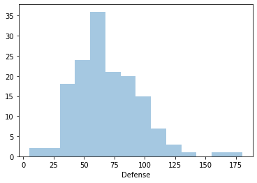

```python
sns.distplot(ourdata1['Defense'],kde=False)
```

**we can also use only the kde plot to plot only kde**

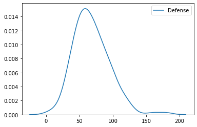

```python
sns.kdeplot(ourdata1['Defense'])
plt.show()
```

**we can as well shade the kde for better visualisation by using shade=True**

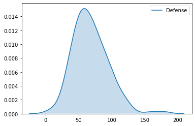

```python
sns.kdeplot(ourdata1['Defense'], shade=True)  #by saying shade=True allows you to shade the area under the curve for better view
plt.show()
```

## **bivariate distributions-visualisations**

**Jointplot**

```python
ourdata.head()
```

|  | Name | Type 1 | Type 2 | Total | HP | Attack | Defense | Atk | Def | Speed | Stage | Legendary |
| --- | --- | --- | --- | --- | --- | --- | --- | --- | --- | --- | --- | --- |
| 0 | Bulbasaur | Grass | Poison | 318 | 45 | 49 | 49 | 65 | 65 | 45 | 1 | False |
| 1 | Ivysaur | Grass | Poison | 405 | 60 | 62 | 63 | 80 | 80 | 60 | 2 | False |
| 2 | Venusaur | Grass | Poison | 525 | 80 | 82 | 83 | 100 | 100 | 80 | 3 | False |
| 3 | Charmander | Fire | NaN | 309 | 39 | 52 | 43 | 60 | 50 | 65 | 1 | False |
| 4 | Charmeleon | Fire | NaN | 405 | 58 | 64 | 58 | 80 | 65 | 80 | 2 | False |

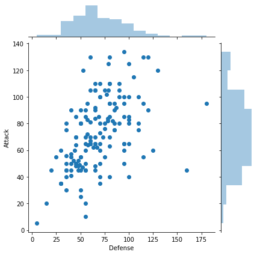

```python
sns.jointplot(ourdata['Defense'], ourdata['Attack'])
```

As you can see a histogram plotted for Defense and another created for Attack, with a scatter plot created between Defense and Attack

**confirm their correlation**

```python
ourdata1[['Defense','Attack']].corr()
```

|  | Defense | Attack |
| --- | --- | --- |
| Defense | 1.000000 | 0.491965 |
| Attack | 0.491965 | 1.000000 |

**We can also explicitly set the 'kind' of visualisation to be displayed**

e.g: kind= “scatter” or “reg” or “resid” or “kde” or “hex”

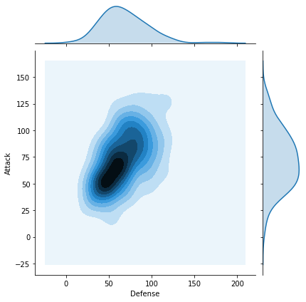

```python
#NB: use shift and tab to get more info about a particular function

sns.jointplot(ourdata['Defense'], ourdata['Attack'], kind='kde')
plt.show()
```

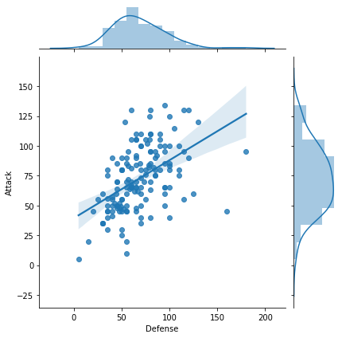

```python
sns.jointplot(ourdata['Defense'], ourdata['Attack'], kind='reg')
plt.show()

#good when you want to explain the residuals
```

### **Visaulising more than two variables: Pairwise Bivariate Distributions-Using Pairplot()**

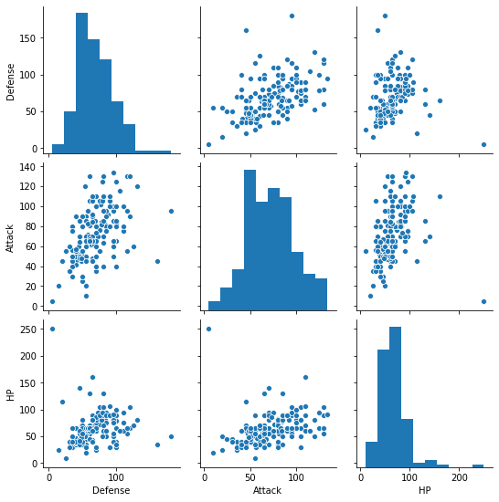

```python
sns.pairplot(ourdata[['Defense','Attack','HP']],kind='scatter')
plt.show()
```

**You can change the diagonal kind**

Let's try diag_kind='kde'

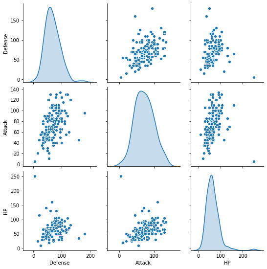

```python
sns.pairplot(ourdata[['Defense','Attack','HP']], kind='scatter', diag_kind ='kde')
plt.show()
```

```python
ourdata.head()
```

|  | Name | Type 1 | Type 2 | Total | HP | Attack | Defense | Atk | Def | Speed | Stage | Legendary |
| --- | --- | --- | --- | --- | --- | --- | --- | --- | --- | --- | --- | --- |
| 0 | Bulbasaur | Grass | Poison | 318 | 45 | 49 | 49 | 65 | 65 | 45 | 1 | False |
| 1 | Ivysaur | Grass | Poison | 405 | 60 | 62 | 63 | 80 | 80 | 60 | 2 | False |
| 2 | Venusaur | Grass | Poison | 525 | 80 | 82 | 83 | 100 | 100 | 80 | 3 | False |
| 3 | Charmander | Fire | NaN | 309 | 39 | 52 | 43 | 60 | 50 | 65 | 1 | False |
| 4 | Charmeleon | Fire | NaN | 405 | 58 | 64 | 58 | 80 | 65 | 80 | 2 | False |

## Categorical Data Visualisation

```python
data=pd.read_csv('Automobile.csv')
```

```python
data.head()
```

|  | symboling | normalized_losses | make | fuel_type | aspiration | number_of_doors | body_style | drive_wheels | engine_location | wheel_base | ... | engine_size | fuel_system | bore | stroke | compression_ratio | horsepower | peak_rpm | city_mpg | highway_mpg | price |
| --- | --- | --- | --- | --- | --- | --- | --- | --- | --- | --- | --- | --- | --- | --- | --- | --- | --- | --- | --- | --- | --- |
| 0 | 3 | 168 | alfa-romero | gas | std | two | convertible | rwd | front | 88.6 | ... | 130 | mpfi | 3.47 | 2.68 | 9.0 | 111 | 5000 | 21 | 27 | 13495 |
| 1 | 3 | 168 | alfa-romero | gas | std | two | convertible | rwd | front | 88.6 | ... | 130 | mpfi | 3.47 | 2.68 | 9.0 | 111 | 5000 | 21 | 27 | 16500 |
| 2 | 1 | 168 | alfa-romero | gas | std | two | hatchback | rwd | front | 94.5 | ... | 152 | mpfi | 2.68 | 3.47 | 9.0 | 154 | 5000 | 19 | 26 | 16500 |
| 3 | 2 | 164 | audi | gas | std | four | sedan | fwd | front | 99.8 | ... | 109 | mpfi | 3.19 | 3.40 | 10.0 | 102 | 5500 | 24 | 30 | 13950 |
| 4 | 2 | 164 | audi | gas | std | four | sedan | 4wd | front | 99.4 | ... | 136 | mpfi | 3.19 | 3.40 | 8.0 | 115 | 5500 | 18 | 22 | 17450 |

5 rows × 26 columns

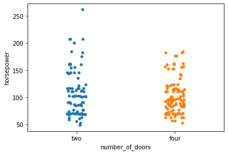

```python
sns.stripplot(data['number_of_doors'], data['horsepower'])
```

Cars with 2 door are having higher horsepower than cars with 4 door

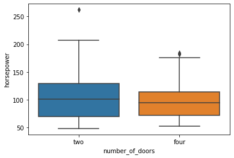

```python
sns.boxplot(data['number_of_doors'], data['horsepower'])
```

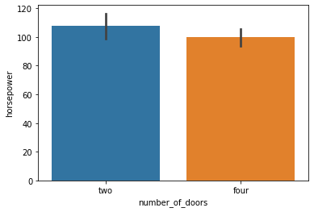

```python
sns.barplot(data['number_of_doors'], data['horsepower'])
```

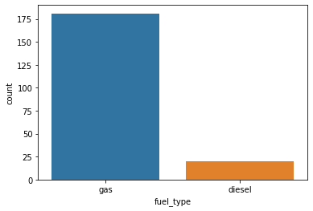

```python
sns.countplot(data['fuel_type'])
```

Perform similar operations with the other variables

Read more: https://seaborn.pydata.org/introduction.html